# Mood Disorder & Suicidality Outcome Variable EDA

Sam A. Sievertsen

2025-07-02

# Exploratory Data Analysis (EDA) of variables to be used as outcome metrics related to mood disorders and suicidality in the ABCD dataset

The most up to date list of variables to used as outcomes in the current study, including their role, domain, details of each variable as it relates to the ABCD dataset, etc., can be found here.

The following report contains information regarding the:

1. Integrity of the data
2. Assessment of outliers in the data
3. Skewness + appropriateness of the mean as the measure of central tendency for continuous variables
4. Shape of each variables’ distribution
5. Distribution of Past-Only vs. Current Diagnoses by Timepoint
6. Transitions: Who “Drops Out” vs. Who “Converts In” at Adjacent Timepoints
7. Transitions Between Diagnostic Sub-Categories
8. Tiered Bipolar‐Spectrum Definitions & Their Stability
9. Clarifying Bipolar NOS Diagnoses
10. Operationalization of Outcome Variables

## Data Wrangling

This section prepares the data for EDA of outcomes via the following process:

[output not shown]

**Why we rescore Bipolar I/II “past episode manic/hypomanic” flags**

The ABCD Study’s KSADS-COMP v1.0 over-diagnoses Lifetime Bipolar-I by allowing a *single* past manic flag to qualify. [Barch et al. (2021)](https://doi.org/10.1016/j.dcn.2021.101031) note:

```
  > “The computerized KSADS 1.0 shows **higher than expected rates** of caregiver- and youth-reported *past manic episodes* (e.g., caregiver-reported prevalence of Bipolar I Disorder, most recent past episode manic is 2.6%). We recommend rescoring such cases so that the youth must also meet criteria…
```

Following this recommendation we:

- restrict rescoring to baseline and 2-year follow-up waves (those using KSADS-v1 past-episode items);
- require any lifetime MDD/PDD flag alongside past mania/hypomania before endorsing Bipolar I or II.

This likely yields more realistic prevalence estimates while keeping current-episode diagnoses intact and preserving the longitudinal structure needed for survival and mixed-effects models.

## 1. Integrity of the Data

The purpose of this section is to complete the following:

[output not shown]

Why we do this:

- Quickly spot variables with excessive missingness (e.g., 70% complete) before they enter survival or mixed-effects models
- Ensure CBCL scores are within valid T-score bounds (~20-80) and that binary outcomes only contain 0/1

| Variable | N Non-Missing | Percent Non-Missing | Range/Unique Values |
| --- | --- | --- | --- |
| bipolar_I | 42510 | 50.985 | 0, 1 |
| bipolar_II | 42510 | 50.985 | 0, 1 |
| any_bsd | 42510 | 50.985 | 0, 1 |
| si_passive | 81539 | 97.794 | 0, 1 |
| si_active | 81539 | 97.794 | 0, 1 |
| sa | 81539 | 97.794 | 0, 1 |
| nssi | 81539 | 97.794 | 0, 1 |
| mh_p_cbcl__dsm__dep_tscore | 67029 | 80.392 | 50, 96 |
| mh_p_cbcl__dsm__anx_tscore | 67490 | 80.945 | 50, 100 |
| mh_p_cbcl__synd__attn_tscore | 80434 | 96.469 | 50, 100 |
| mh_p_cbcl__synd__aggr_tscore | 80440 | 96.476 | 50, 100 |

## 2. Visually and Quantitatively Assess for any Outliers in the Data

The purpose of this section is to:

[output not shown]

Why we do this:

- Box-plots give an immediate visual flag for values that lie well outside the typical CBCL range (e.g., < 30 or > 100).
- Faceting four plots in one view is an efficient QC step before deciding on transformations or winsorisation.

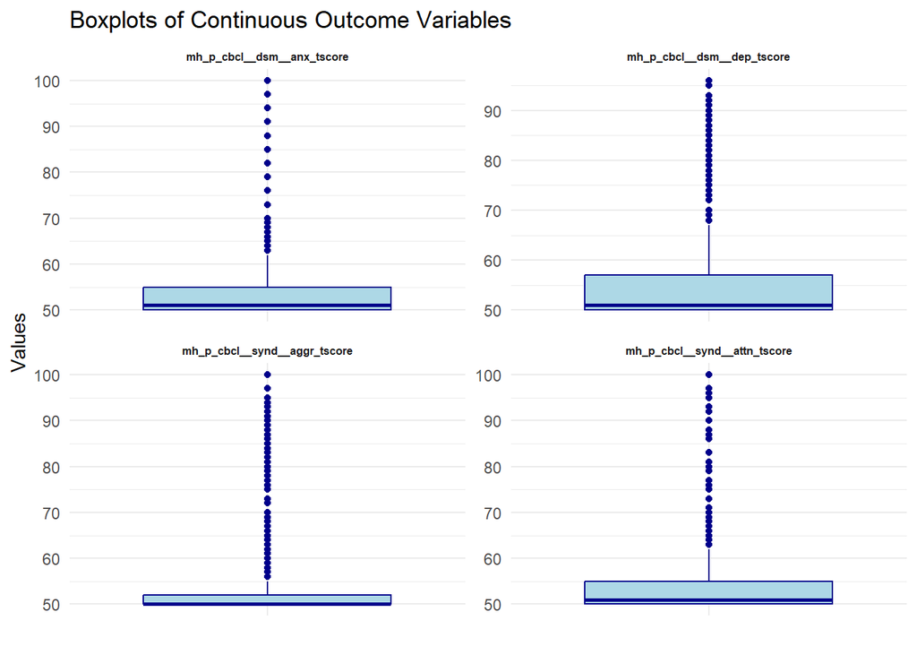

Based on the boxplots of the continuous (secondary) outcome variables, it does not appear as though any values are out of range or otherwise unexpected outliers. However, it does appear as if the data is not normally distributed, and this should be thoroughly assessed in subsequent steps.

## 3. Appropriateness of the Mean as a Measure of Central Tendency

While clustering methods used in this study do not require parametric assumptions, the secondary continuous outcome measures - `cbcl_scr_dsm5_depress_t`, `cbcl_scr_dsm5_anxdisord_t`, `cbcl_scr_syn_attention_t`, and `cbcl_scr_syn_aggressive_t` - will serve as dependent variables in statistical models that do. Therefore, examining kurtosis & skewness provides information about the asymmetry of these variable distributions, which may help identify variables with extreme outliers or long tails (and therefore any adaptations that should be made to our statistical analysis pipeline).

Below, skewness & kurtosis values for the four secondary outcome measures are presented.

Skewness & Kurtosis Values for Continuous Variables

| Variable | skewness | kurtosis |
| --- | --- | --- |
| mh_p_cbcl__dsm__dep_tscore | 1.67 | 5.55 |
| mh_p_cbcl__dsm__anx_tscore | 2.25 | 8.68 |
| mh_p_cbcl__synd__attn_tscore | 2.47 | 10.72 |
| mh_p_cbcl__synd__aggr_tscore | 3.17 | 15.35 |

**All four outcomes show the typical CBCL pattern; strong positive skew and heavy tails, because most community youth score low while a small clinical subgroup stretches the right tail**

Implications for the longitudinal mixed-effects models:

| Option | When to choose | Quick note |
| --- | --- | --- |
| **Keep raw T-scores + robust / bootstrap SEs** | Large sample, focus on mean differences | Central-limit theorem handles skew; report Satterthwaite or bootstrap CIs |
| **Mild transform (√ or log)** | Residual QQ-plots still show heavy tail or heteroscedasticity | Transform, refit LMM, compare AIC/BIC |
| **Non-Gaussian GLMM (e.g., gamma)** | Skew remains problematic after transforms or transforms don’t make sense | Fit with `glmmTMB` |

Suggested workflow for analyses:

1. Fit the base LMM on raw T-scores with robust SEs
2. Inspect residual QQ-plots and variance-vs-fitted
3. If diagnostics are poor, apply √/log transform and refit; record any change in inference
4. Document choice and likely include GLMM sensitivity in the supplement anyway

## 4. Shape of Each Variables’ Distribution

The shape of the distribution for each continuous variable and frequency distribution of each categorical variable is outlined below, both in terms of summary statistics derived from and a graphical histogram with density overlay of relevant data:

Summary Statistics for Outcome Model Variables by Assessment Timepoint

| Timepoint | Variable | Type | N | Mean | Median | SD | Min | Max | Levels | Frequencies |
| --- | --- | --- | --- | --- | --- | --- | --- | --- | --- | --- |
| **ses-00A** |  |  |  |  |  |  |  |  |  |  |
| ses-00A | mh_p_cbcl__dsm__dep_tscore | Continuous | 11871 | 53.600708 | 50 | 5.7285945 | 50 | 89 | NA | NA |
| ses-00A | mh_p_cbcl__dsm__anx_tscore | Continuous | 11871 | 53.493219 | 51 | 6.1271366 | 50 | 97 | NA | NA |
| ses-00A | mh_p_cbcl__synd__attn_tscore | Continuous | 11871 | 53.903799 | 51 | 6.1674482 | 50 | 100 | NA | NA |
| ses-00A | mh_p_cbcl__synd__aggr_tscore | Continuous | 11870 | 52.833193 | 50 | 5.5332063 | 50 | 100 | NA | NA |
| ses-00A | bipolar_I | Categorical | 11877 | NA | NA | NA | NA | NA | 0, 1 | 11772, 105 |
| ses-00A | bipolar_II | Categorical | 11877 | NA | NA | NA | NA | NA | 0, 1 | 11845, 32 |
| ses-00A | any_bsd | Categorical | 11877 | NA | NA | NA | NA | NA | 0, 1 | 10755, 1122 |
| ses-00A | si_passive | Categorical | 11877 | NA | NA | NA | NA | NA | 0, 1 | 10514, 1363 |
| ses-00A | si_active | Categorical | 11877 | NA | NA | NA | NA | NA | 0, 1 | 10992, 885 |
| ses-00A | sa | Categorical | 11877 | NA | NA | NA | NA | NA | 0, 1 | 11683, 194 |
| ses-00A | nssi | Categorical | 11877 | NA | NA | NA | NA | NA | 0, 1 | 10807, 1070 |
| **ses-01A** |  |  |  |  |  |  |  |  |  |  |
| ses-01A | mh_p_cbcl__dsm__dep_tscore | Continuous | 11105 | 53.952724 | 52 | 6.1077042 | 50 | 89 | NA | NA |
| ses-01A | mh_p_cbcl__dsm__anx_tscore | Continuous | 11125 | 53.556674 | 51 | 6.2399543 | 50 | 97 | NA | NA |
| ses-01A | mh_p_cbcl__synd__attn_tscore | Continuous | 11214 | 53.716158 | 51 | 5.9768089 | 50 | 96 | NA | NA |
| ses-01A | mh_p_cbcl__synd__aggr_tscore | Continuous | 11214 | 52.585875 | 50 | 5.2946770 | 50 | 95 | NA | NA |
| ses-01A | si_passive | Categorical | 11876 | NA | NA | NA | NA | NA | 0, 1 | 11158, 718 |
| ses-01A | si_active | Categorical | 11876 | NA | NA | NA | NA | NA | 0, 1 | 11377, 499 |
| ses-01A | sa | Categorical | 11876 | NA | NA | NA | NA | NA | 0, 1 | 11734, 142 |
| ses-01A | nssi | Categorical | 11876 | NA | NA | NA | NA | NA | 0, 1 | 11343, 533 |
| **ses-02A** |  |  |  |  |  |  |  |  |  |  |
| ses-02A | mh_p_cbcl__dsm__dep_tscore | Continuous | 9520 | 54.354832 | 51 | 6.2077303 | 50 | 93 | NA | NA |
| ses-02A | mh_p_cbcl__dsm__anx_tscore | Continuous | 9658 | 53.809484 | 51 | 6.1547764 | 50 | 100 | NA | NA |
| ses-02A | mh_p_cbcl__synd__attn_tscore | Continuous | 10919 | 53.535214 | 51 | 5.6686794 | 50 | 97 | NA | NA |
| ses-02A | mh_p_cbcl__synd__aggr_tscore | Continuous | 10918 | 52.363894 | 50 | 4.9931826 | 50 | 95 | NA | NA |
| ses-02A | bipolar_I | Categorical | 11796 | NA | NA | NA | NA | NA | 0, 1 | 11727, 69 |
| ses-02A | bipolar_II | Categorical | 11796 | NA | NA | NA | NA | NA | 0, 1 | 11767, 29 |
| ses-02A | any_bsd | Categorical | 11796 | NA | NA | NA | NA | NA | 0, 1 | 11270, 526 |
| ses-02A | si_passive | Categorical | 11796 | NA | NA | NA | NA | NA | 0, 1 | 10552, 1244 |

[output cut: 63 more lines]

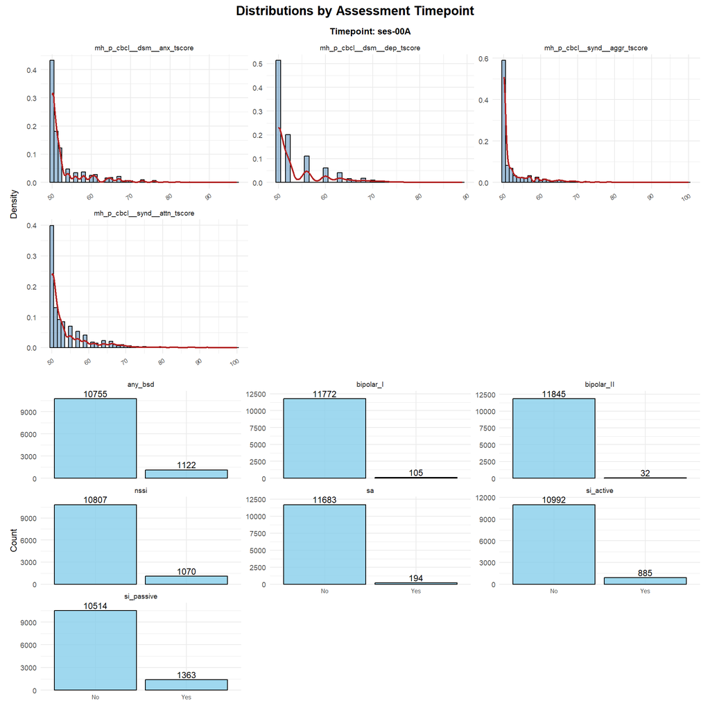

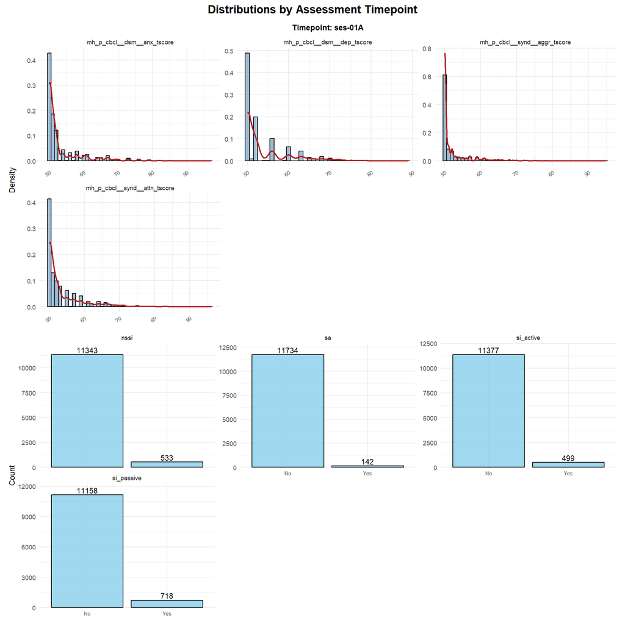

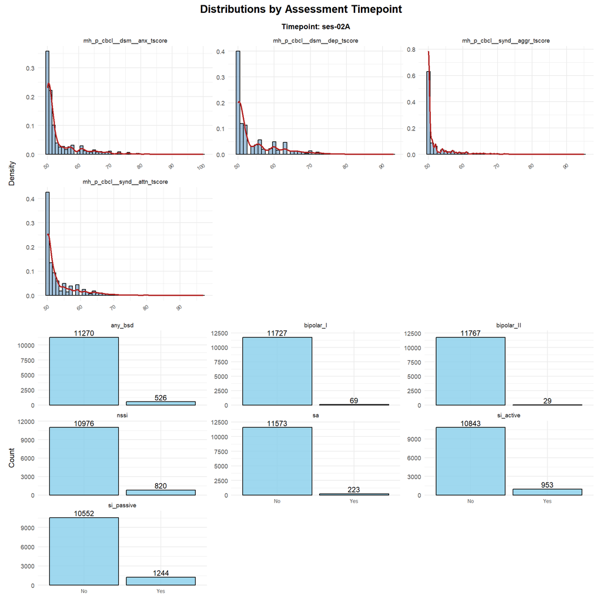

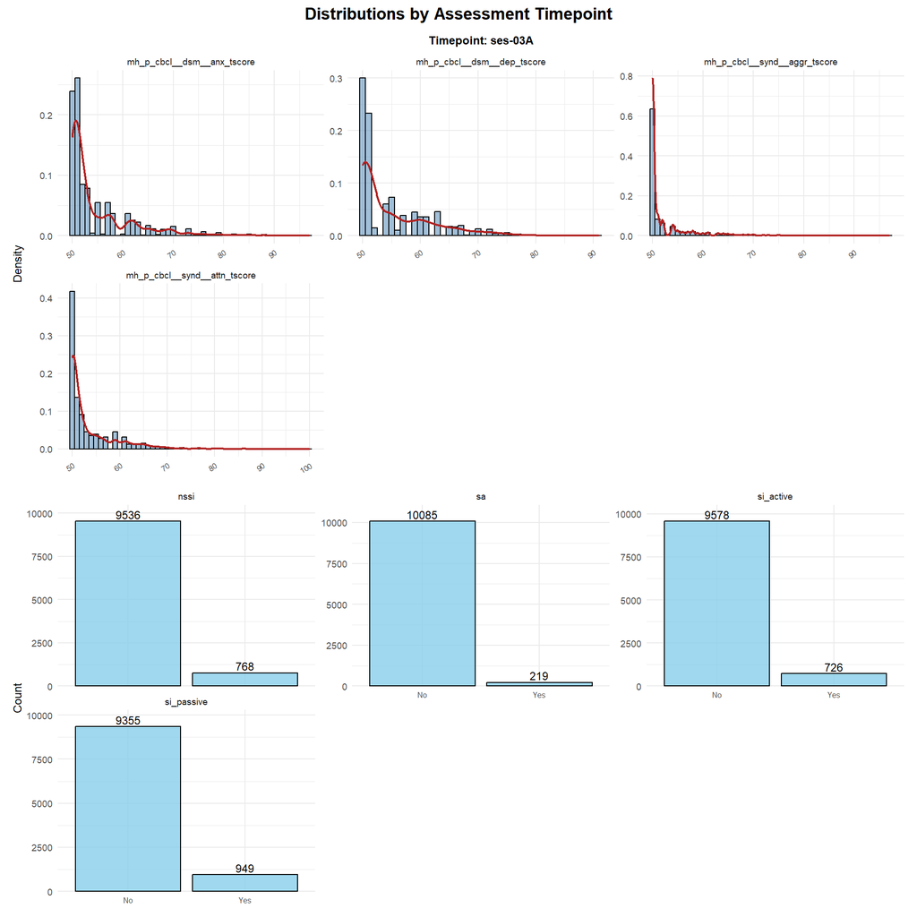

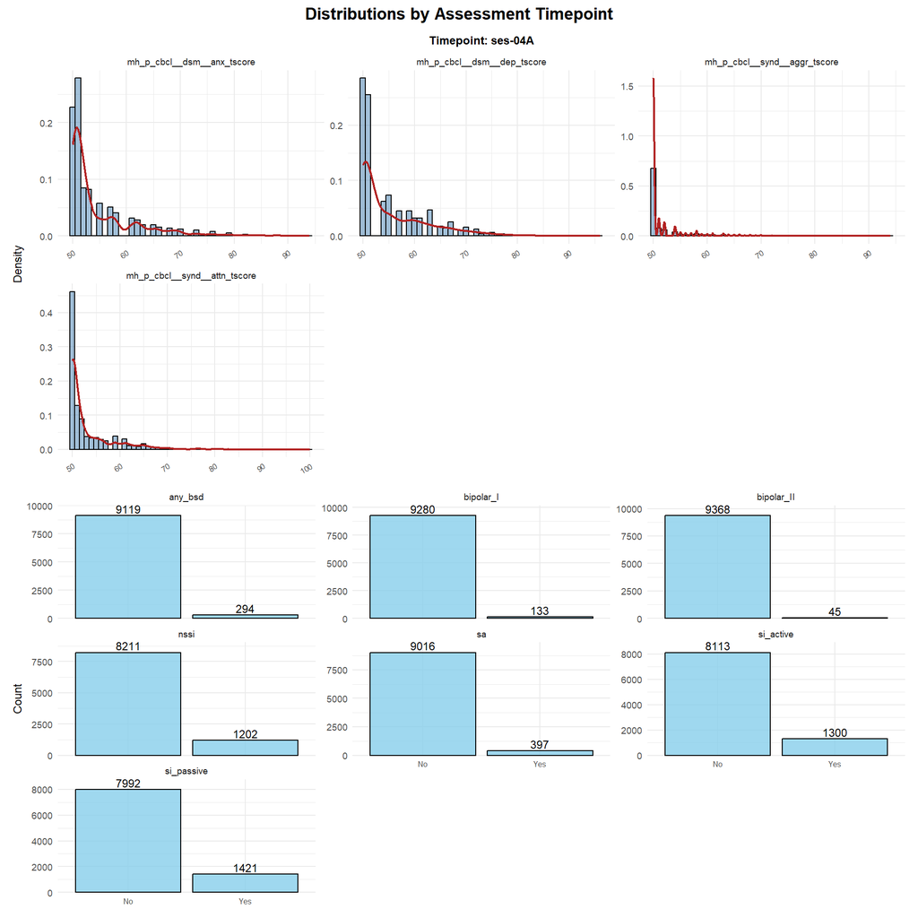

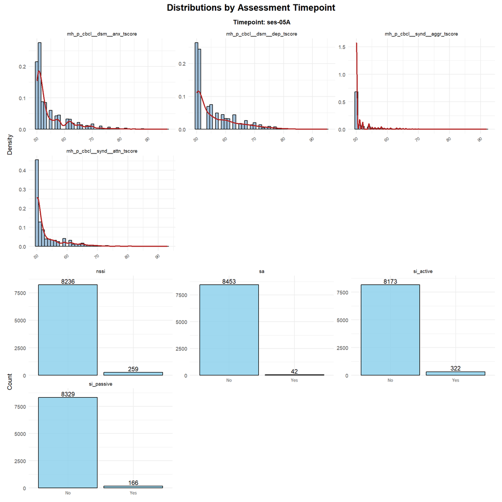

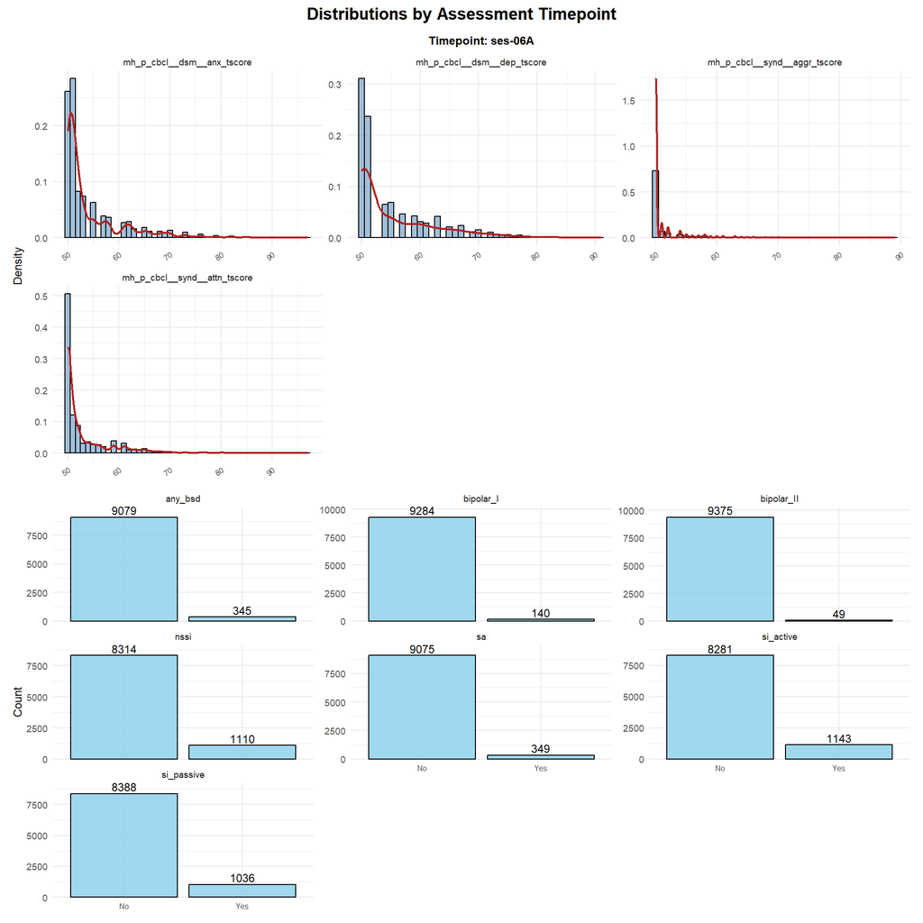

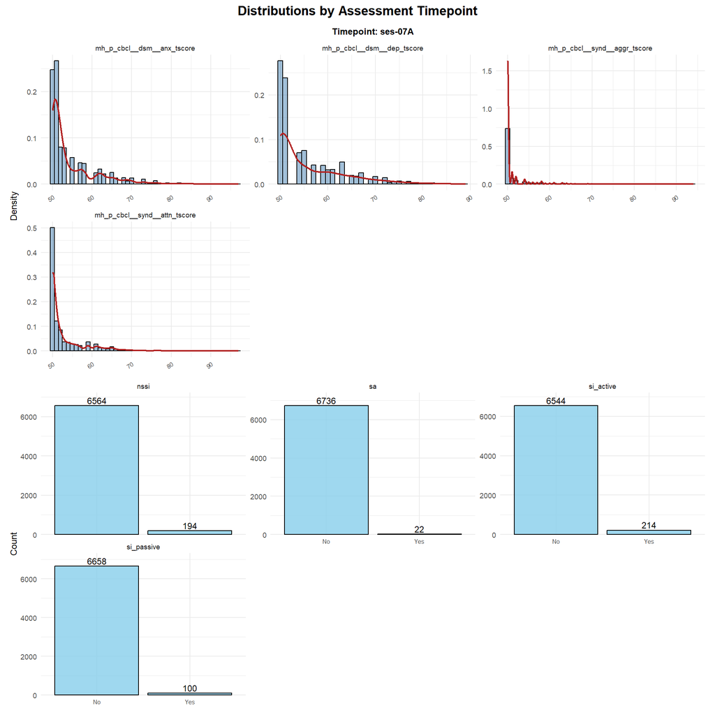

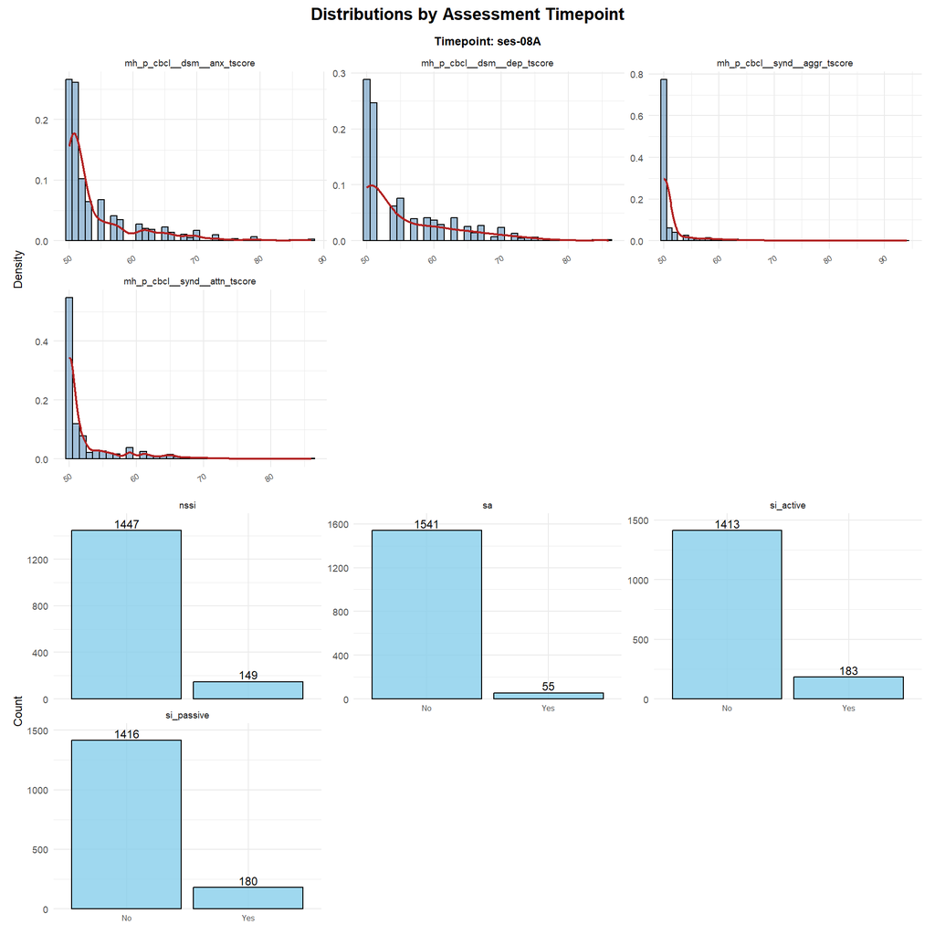

Distributions of continuous variables and rates of categorical variables by timepoint are shown above. While continuous variables exhibit noticeable skew & kurtosis, and the CBCL aggression problem scale results will need to be interpreted with caution/re-evaluated during modeling as described in section 3 above, no other problems are noted herein.

## 5. Distribution of Past-Only vs. Current Diagnoses by Timepoint

In this section, we split each bipolar diagnosis (and the combined “Any BSD” flag) into two mutually exclusive categories:

1. Current - youth who meet criteria for a manic/hypomanic or depressive episode at that assessment wave.
2. Past‐only - youth who endorse a recent past episode (mania/hypomania or “unspecified” bipolar) but do not currently meet criteria for a mood episode

By tabulating both raw counts and percentages of “current” versus “past‐only” cases at each session, we can see how much of our baseline and follow-up prevalence is driven by active illness versus residual history. This helps contextualize any inflated “Any BSD” rates at early waves and ensures we understand whether “past‐only” cases drop out of the bipolar spectrum once they no longer meet full criteria.

Counts & Percentages of Current vs. Past-Only Diagnoses by Session

| Session | Diagnosis | Timing | N | Total N | Percent |
| --- | --- | --- | --- | --- | --- |
| ses-00A | any_bsd | current | 235 | 11878 | 2.0 |
| ses-01A | any_bsd | current | 0 | 11877 | 0.0 |
| ses-02A | any_bsd | current | 129 | 11797 | 1.1 |
| ses-03A | any_bsd | current | 0 | 10513 | 0.0 |
| ses-04A | any_bsd | current | 243 | 9799 | 2.5 |
| ses-05A | any_bsd | current | 0 | 9044 | 0.0 |
| ses-06A | any_bsd | current | 300 | 9525 | 3.1 |
| ses-07A | any_bsd | current | 0 | 7182 | 0.0 |
| ses-08A | any_bsd | current | 0 | 1763 | 0.0 |
| ses-00A | any_bsd | pastonly | 904 | 11878 | 7.6 |
| ses-01A | any_bsd | pastonly | 0 | 11877 | 0.0 |
| ses-02A | any_bsd | pastonly | 409 | 11797 | 3.5 |
| ses-03A | any_bsd | pastonly | 0 | 10513 | 0.0 |
| ses-04A | any_bsd | pastonly | 51 | 9799 | 0.5 |
| ses-05A | any_bsd | pastonly | 0 | 9044 | 0.0 |
| ses-06A | any_bsd | pastonly | 45 | 9525 | 0.5 |
| ses-07A | any_bsd | pastonly | 0 | 7182 | 0.0 |
| ses-08A | any_bsd | pastonly | 0 | 1763 | 0.0 |
| ses-00A | bipolar_I | current | 81 | 11878 | 0.7 |
| ses-01A | bipolar_I | current | 0 | 11877 | 0.0 |
| ses-02A | bipolar_I | current | 46 | 11797 | 0.4 |
| ses-03A | bipolar_I | current | 0 | 10513 | 0.0 |
| ses-04A | bipolar_I | current | 89 | 9799 | 0.9 |
| ses-05A | bipolar_I | current | 0 | 9044 | 0.0 |
| ses-06A | bipolar_I | current | 102 | 9525 | 1.1 |
| ses-07A | bipolar_I | current | 0 | 7182 | 0.0 |
| ses-08A | bipolar_I | current | 0 | 1763 | 0.0 |
| ses-00A | bipolar_I | pastonly | 28 | 11878 | 0.2 |
| ses-01A | bipolar_I | pastonly | 0 | 11877 | 0.0 |
| ses-02A | bipolar_I | pastonly | 24 | 11797 | 0.2 |
| ses-03A | bipolar_I | pastonly | 0 | 10513 | 0.0 |
| ses-04A | bipolar_I | pastonly | 45 | 9799 | 0.5 |
| ses-05A | bipolar_I | pastonly | 0 | 9044 | 0.0 |
| ses-06A | bipolar_I | pastonly | 39 | 9525 | 0.4 |
| ses-07A | bipolar_I | pastonly | 0 | 7182 | 0.0 |
| ses-08A | bipolar_I | pastonly | 0 | 1763 | 0.0 |
| ses-00A | bipolar_II | current | 38 | 11878 | 0.3 |
| ses-01A | bipolar_II | current | 0 | 11877 | 0.0 |
| ses-02A | bipolar_II | current | 24 | 11797 | 0.2 |
| ses-03A | bipolar_II | current | 0 | 10513 | 0.0 |
| ses-04A | bipolar_II | current | 37 | 9799 | 0.4 |
| ses-05A | bipolar_II | current | 0 | 9044 | 0.0 |
| ses-06A | bipolar_II | current | 42 | 9525 | 0.4 |
| ses-07A | bipolar_II | current | 0 | 7182 | 0.0 |
| ses-08A | bipolar_II | current | 0 | 1763 | 0.0 |
| ses-00A | bipolar_II | pastonly | 17 | 11878 | 0.1 |
| ses-01A | bipolar_II | pastonly | 0 | 11877 | 0.0 |
| ses-02A | bipolar_II | pastonly | 24 | 11797 | 0.2 |
| ses-03A | bipolar_II | pastonly | 0 | 10513 | 0.0 |
| ses-04A | bipolar_II | pastonly | 8 | 9799 | 0.1 |
| ses-05A | bipolar_II | pastonly | 0 | 9044 | 0.0 |
| ses-06A | bipolar_II | pastonly | 7 | 9525 | 0.1 |
| ses-07A | bipolar_II | pastonly | 0 | 7182 | 0.0 |
| ses-08A | bipolar_II | pastonly | 0 | 1763 | 0.0 |

In Section 5, we observe that “Any BSD” and individual bipolar diagnoses generally show their highest prevalence at baseline (ses-00A), with a substantial portion initially classified as “past-only.” Specifically:

- Any BSD
  - ses-00A: 2.0% currently met criteria (235 / 11,878) and 7.6% had past-only BSD (904 / 11,878)
  - ses-02A: current fell to 1.1% (129 / 11,797), past-only to 3.5% (409 / 11,797)
  - ses-04A: current rose to 2.5% (243 / 9,799), past-only held at 0.5% (51 / 9,799)
  - ses-06A: current at 3.1% (300 / 9,525), past-only at 0.5% (45 / 9,525)
- BD-I
  - ses-00A: 0.7% current (81 / 11,878), 0.2% past-only (28 / 11,878)
  - ses-02A: 0.4% current (46 / 11,797), 0.2% past-only (24 / 11,797)
  - ses-04A: 0.9% current (89 / 9,799), 0.5% past-only (45 / 9,799)
  - ses-06A: 1.1% current (102 / 9,525), 0.4% past-only (39 / 9,525)
- BD-II
  - ses-00A: 0.3% current (38 / 11,878), 0.1% past-only (17 / 11,878)
  - ses-02A: 0.2% current (24 / 11,797), 0.2% past-only (24 / 11,797)
  - ses-04A: 0.4% current (37 / 9,799), 0.1% past-only (8 / 9,799)
  - ses-06A: 0.4% current (42 / 9,525), 0.1% past-only (7 / 9,525)

After the shift to KSADS-COMP v2.0 (post-ses-02A), “past-only” flags remained very low (< 1%) while “current” rates for Any BSD and BD-I rose modestly—likely reflecting improved measurement combined with developmentally expected increases in the emergence of the disorder.

## 6. Transitions: Who “Drops Out” vs. Who “Converts In” at Adjacent Timepoints

Here we examine longitudinal transitions in each bipolar diagnosis (and Any BSD) between consecutive assessment waves. Specifically, we identify:

- Dropped Out: Youth who had the diagnosis at time *t* but no longer meet criteria at time *t+1*
- New On: Youth who did not have the diagnosis at time *t* but do meet criteria at time *t+1*
- Still Has / Still No: Youth who either continue to have or continue not to have the diagnosis across the two waves

By tabulating raw counts and percentages for each “From → To” pair (e.g., ses-00A → ses-02A), we can quantify how many cases resolve or emerge over time. This helps clarify the stability versus fluctuation of bipolar diagnoses (and combined BSD) across our follow-up waves

Transition Counts & Percentages Between Consecutive Sessions

| Diagnosis | From | To | N Dropped | % dropped (of Time1) | N NewOn | % new (of Time2) | Still Has | Still No |
| --- | --- | --- | --- | --- | --- | --- | --- | --- |
| bipolar_I | ses-00A | ses-02A | 100 | 95.2 | 64 | 92.8 | 5 | 11709 |
| bipolar_I | ses-02A | ses-04A | 65 | 94.2 | 129 | 97.0 | 4 | 11680 |
| bipolar_I | ses-04A | ses-06A | 127 | 95.5 | 134 | 95.7 | 6 | 11611 |
| bipolar_II | ses-00A | ses-02A | 31 | 96.9 | 28 | 96.6 | 1 | 11818 |
| bipolar_II | ses-02A | ses-04A | 29 | 100.0 | 45 | 100.0 | 0 | 11804 |
| bipolar_II | ses-04A | ses-06A | 43 | 95.6 | 47 | 95.9 | 2 | 11786 |
| any_bsd | ses-00A | ses-02A | 1011 | 90.1 | 415 | 78.9 | 111 | 10341 |
| any_bsd | ses-02A | ses-04A | 495 | 94.1 | 263 | 89.5 | 31 | 11089 |
| any_bsd | ses-04A | ses-06A | 255 | 86.7 | 306 | 88.7 | 39 | 11278 |

In sum, very few youth with Bipolar I/II (or Any BSD) remained positive across waves: most earlier cases “dropped out,” and the vast majority of later cases were new onset. This underscores substantial diagnostic turnover rather than persistence across the available follow-ups. No diagnoses were collected in odd-numbered years, so transitions are shown only for even-year intervals

## 7. Transitions Between Diagnostic Categories

In this section, we create a multi‐state variable that encodes each youth’s bipolar spectrum diagnosis at each wave (No BSD, BD-I, BD-II, Other/Unspecified BSD), then compute the full transition matrix between consecutive waves. This allows us to quantify flows such as BD-I → BD-II, Other BSD → BD-I, etc., both in raw counts and as percentages of the “From” category

Transition Counts & Percentages Between Diagnostic States

| From | NoBSD | BD1 | BD2 | OtherBSD |
| --- | --- | --- | --- | --- |
| **ses-00A→ses-02A** |  |  |  |  |
| NoBSD | 10249 (96.1%) | 55 (0.5%) | 23 (0.2%) | 342 (3.2%) |
| BD1 | 91 (87.5%) | 5 (4.8%) | 4 (3.8%) | 4 (3.8%) |
| BD2 | 41 (85.4%) | 1 (2.1%) | 2 (4.2%) | 4 (8.3%) |
| OtherBSD | 878 (90%) | 9 (0.9%) | 9 (0.9%) | 80 (8.2%) |
| **ses-02A→ses-04A** |  |  |  |  |
| NoBSD | 9076 (97.2%) | 121 (1.3%) | 42 (0.4%) | 100 (1.1%) |
| BD1 | 42 (76.4%) | 5 (9.1%) | 1 (1.8%) | 7 (12.7%) |
| BD2 | 28 (93.3%) | 2 (6.7%) | 0 (0%) | 0 (0%) |
| OtherBSD | 358 (95.7%) | 5 (1.3%) | 2 (0.5%) | 9 (2.4%) |
| **ses-04A→ses-06A** |  |  |  |  |
| NoBSD | 8257 (96.9%) | 112 (1.3%) | 35 (0.4%) | 120 (1.4%) |
| BD1 | 98 (83.8%) | 6 (5.1%) | 3 (2.6%) | 10 (8.5%) |
| BD2 | 35 (85.4%) | 3 (7.3%) | 2 (4.9%) | 1 (2.4%) |
| OtherBSD | 86 (86%) | 4 (4%) | 4 (4%) | 6 (6%) |
| **ses-06A→ses-08A** |  |  |  |  |
| NoBSD | 1573 (100%) | 0 (0%) | 0 (0%) | 0 (0%) |
| BD1 | 27 (100%) | 0 (0%) | 0 (0%) | 0 (0%) |
| BD2 | 6 (100%) | 0 (0%) | 0 (0%) | 0 (0%) |
| OtherBSD | 26 (100%) | 0 (0%) | 0 (0%) | 0 (0%) |

```
Sankey Diagram of Transition Counts Between Diagnostic States
```

[interactive chart not shown]

Across each consecutive assessment wave, most youth without a bipolar diagnosis remained stable (~97% NoBSD→NoBSD), though small numbers transitioned into BD-I, BD-II, or Other/Unspecified BSD categories (0.2-3.2%).

Youth initially diagnosed with BD-I, BD-II, or Other BSD demonstrated high diagnostic instability. For example, between baseline and the 2-year follow-up, 87.5% of BD-I youth transitioned to NoBSD, with similarly high rates for BD-II (85.4%) and OtherBSD (90%). This pattern persisted across subsequent follow-ups, reflecting substantial flux rather than diagnostic persistence, particularly notable in transitions from diagnostic categories back to No BSD.

Another informative spot check is how many youth have any BSD at multiple timepoints. In brief, 1,793 (15.1%) participants have any BSD at any 1 of the timepoints; 229 (1.9%) participants have any BSD at 2 timepoints; 19 (0.16%) participants have any BSD at 3 timepoints; and 2 (0.01%) participants have any BSD at all 4 timepoints.

## 8. Tiered Bipolar‐Spectrum Definitions & Their Stability

As forms of potential sensitivity analyses and to increase the specificity and sensitivity in our BSD cases, we define four “tiers” of increasing diagnostic stringency at each assessment timepoint to compare to just KSADS-COMP derived diagnoses:

1. **Tier 1**: All four CBCL subscales (depression, anxiety, attention, aggression) >= 65 T-score
2. **Tier 2**: Tier 1 **+** GBI Mania total >= 12
3. **Tier 3**: KSADS any BSD (current or past-only) **+** Tier 1
4. **Tier 4**: KSADS any BSD **+** Tier 1 **+** GBI Mania >= 12

We then count, for each youth, at how many of the four timepoints of interest (baseline, 2-year, 4-year, and 6-year follow-ups) they meet each tier, and display the distribution of those counts.

Prevalence of Each Tier by Wave

| Session | Tier | N Endorsed | Total N | % Endorsed |
| --- | --- | --- | --- | --- |
| **Tier1 (CBCL BD Profile >= 65)** |  |  |  |  |
| ses-00A | tier1 | 143 | 11878 | 1.20 |
| ses-01A | tier1 | 134 | 11877 | 1.13 |
| ses-02A | tier1 | 96 | 11797 | 0.81 |
| ses-03A | tier1 | 104 | 10513 | 0.99 |
| ses-04A | tier1 | 76 | 9799 | 0.78 |
| ses-05A | tier1 | 93 | 9044 | 1.03 |
| ses-06A | tier1 | 57 | 9525 | 0.60 |
| ses-07A | tier1 | 30 | 7182 | 0.42 |
| ses-08A | tier1 | 12 | 1763 | 0.68 |
| **Tier2 (+GBI Mania >= 12)** |  |  |  |  |
| ses-00A | tier2 | 57 | 11878 | 0.48 |
| ses-01A | tier2 | 57 | 11877 | 0.48 |
| ses-02A | tier2 | 34 | 11797 | 0.29 |
| ses-03A | tier2 | 0 | 10513 | 0.00 |
| ses-04A | tier2 | 21 | 9799 | 0.21 |
| ses-05A | tier2 | 36 | 9044 | 0.40 |
| ses-06A | tier2 | 18 | 9525 | 0.19 |
| ses-07A | tier2 | 8 | 7182 | 0.11 |
| ses-08A | tier2 | 3 | 1763 | 0.17 |
| **Tier3 (+KSADS Any BSD)** |  |  |  |  |
| ses-00A | tier3 | 46 | 11878 | 0.39 |
| ses-01A | tier3 | 0 | 11877 | 0.00 |
| ses-02A | tier3 | 28 | 11797 | 0.24 |
| ses-03A | tier3 | 0 | 10513 | 0.00 |
| ses-04A | tier3 | 9 | 9799 | 0.09 |
| ses-05A | tier3 | 0 | 9044 | 0.00 |
| ses-06A | tier3 | 8 | 9525 | 0.08 |
| ses-07A | tier3 | 0 | 7182 | 0.00 |
| ses-08A | tier3 | 0 | 1763 | 0.00 |
| **Tier4 (All criteria)** |  |  |  |  |
| ses-00A | tier4 | 18 | 11878 | 0.15 |
| ses-01A | tier4 | 0 | 11877 | 0.00 |
| ses-02A | tier4 | 14 | 11797 | 0.12 |
| ses-03A | tier4 | 0 | 10513 | 0.00 |
| ses-04A | tier4 | 4 | 9799 | 0.04 |
| ses-05A | tier4 | 0 | 9044 | 0.00 |
| ses-06A | tier4 | 3 | 9525 | 0.03 |
| ses-07A | tier4 | 0 | 7182 | 0.00 |
| ses-08A | tier4 | 0 | 1763 | 0.00 |

Tier Transition Counts & Percentages Between Waves

| Tier | From | To | N Dropped | N Still Has | % dropped | N NewOnset | N Still No | % NewOnset |
| --- | --- | --- | --- | --- | --- | --- | --- | --- |
| tier1 | ses-00A | ses-02A | 113 | 30 | 79.0 | 66 | 11669 | 68.8 |
| tier1 | ses-02A | ses-04A | 80 | 16 | 83.3 | 60 | 11722 | 78.9 |
| tier1 | ses-04A | ses-06A | 66 | 10 | 86.8 | 47 | 11755 | 82.5 |
| tier2 | ses-00A | ses-02A | 50 | 7 | 87.7 | 27 | 11794 | 79.4 |
| tier2 | ses-02A | ses-04A | 30 | 4 | 88.2 | 17 | 11827 | 81.0 |
| tier2 | ses-04A | ses-06A | 19 | 2 | 90.5 | 16 | 11841 | 88.9 |
| tier3 | ses-00A | ses-02A | 40 | 6 | 87.0 | 22 | 11810 | 78.6 |
| tier3 | ses-02A | ses-04A | 28 | 0 | 100.0 | 9 | 11841 | 100.0 |
| tier3 | ses-04A | ses-06A | 9 | 0 | 100.0 | 8 | 11861 | 100.0 |
| tier4 | ses-00A | ses-02A | 16 | 2 | 88.9 | 12 | 11848 | 85.7 |
| tier4 | ses-02A | ses-04A | 14 | 0 | 100.0 | 4 | 11860 | 100.0 |
| tier4 | ses-04A | ses-06A | 4 | 0 | 100.0 | 3 | 11871 | 100.0 |

#### Tier 1 - CBCL >=65 on All 4 Subscales

[interactive chart not shown]

#### Tier 2 - Tier 1 + GBI Mania >=12

[interactive chart not shown]

#### Tier 3 - Any BSD + Tier 1

[interactive chart not shown]

#### Tier 4 - Any BSD + Tier 1 + GBI Mania >=12

[interactive chart not shown]

Across the four even-year follow-up timepoints, the tiers are quite low in occurrence rate; and unsurprisingly, the stricter the definition, the rarer each tier is in ABCD.

**Overall**, < 1.5% of the ABCD cohort ever meets Tier 1, < 0.5% meets Tier 2, and Tier 3/Tier 4 occur in only a few dozen participants each wave. Persistence across multiple waves is exceptionally rare (single digit numbers of participants meet Tier 3 or Tier 4 at two consecutive waves). To me, these findings reinforce that even with additional “validation” criteria, bipolar-spectrum indicators in ABCD are infrequent and highly unstable over time. Which is not to say that we shouldn’t trust that our clinical classifications aren’t useful or even that they don’t represent bipolar in a way we wouldn’t expect; just that they are limited by how much we trust their validity & reliability compared to clinician administered diagnoses

Given that the unspecified bipolar and related disorder diagnoses occur in much higher rates than anticipated at the baseline and 2-year follow-up assessment timepoints (when KSADS 1.0 was delivered) and are highly unstable across time, we will do the following to determine whether we can operationalize the unspecified bipolar and related disorder diagnoses from those two timepoints in a manner that allows us to trust the data (i.e., whether subjects with said diagnoses are truly experiencing BD symptomatology):

1. Check whether any assessment sites have inflated rates of these diagnoses
2. Stratify the BD NOS cases by GBI scores > 12 and check what patterns emerge over time (e.g., stability)

As such, we will first examine the rates of BD NOS diagnoses (and BD NOS diagnoses stratified by GBI mania >= 12) at each assessment site:

Site-Level Unspecified BSD Rates by Session

| Site | Session | Total Site N | N BD NOS | % BD NOS | N BD NOS + GBI>=12 | % of NOS w GBI>=12 |
| --- | --- | --- | --- | --- | --- | --- |
| 1 | ses-00A | 406 | 36 | 8.87 | 0 | 0.00 |
| 1 | ses-02A | 398 | 16 | 4.02 | 1 | 6.25 |
| 2 | ses-00A | 558 | 41 | 7.35 | 0 | 0.00 |
| 2 | ses-02A | 562 | 23 | 4.09 | 0 | 0.00 |
| 3 | ses-00A | 631 | 48 | 7.61 | 5 | 10.42 |
| 3 | ses-02A | 621 | 29 | 4.67 | 1 | 3.45 |
| 4 | ses-00A | 744 | 97 | 13.04 | 3 | 3.09 |
| 4 | ses-02A | 743 | 35 | 4.71 | 3 | 8.57 |
| 5 | ses-00A | 378 | 29 | 7.67 | 0 | 0.00 |
| 5 | ses-02A | 383 | 20 | 5.22 | 0 | 0.00 |
| 6 | ses-00A | 583 | 40 | 6.86 | 1 | 2.50 |
| 6 | ses-02A | 576 | 14 | 2.43 | 0 | 0.00 |
| 7 | ses-00A | 339 | 31 | 9.14 | 3 | 9.68 |
| 7 | ses-02A | 337 | 12 | 3.56 | 1 | 8.33 |
| 8 | ses-00A | 350 | 28 | 8.00 | 0 | 0.00 |
| 8 | ses-02A | 349 | 12 | 3.44 | 0 | 0.00 |
| 9 | ses-00A | 434 | 40 | 9.22 | 0 | 0.00 |
| 9 | ses-02A | 427 | 7 | 1.64 | 0 | 0.00 |
| 10 | ses-00A | 737 | 44 | 5.97 | 2 | 4.55 |
| 10 | ses-02A | 729 | 16 | 2.19 | 0 | 0.00 |
| 11 | ses-00A | 448 | 43 | 9.60 | 2 | 4.65 |
| 11 | ses-02A | 453 | 22 | 4.86 | 1 | 4.55 |
| 12 | ses-00A | 604 | 51 | 8.44 | 5 | 9.80 |
| 12 | ses-02A | 600 | 32 | 5.33 | 0 | 0.00 |
| 13 | ses-00A | 728 | 64 | 8.79 | 1 | 1.56 |
| 13 | ses-02A | 714 | 27 | 3.78 | 0 | 0.00 |
| 14 | ses-00A | 602 | 37 | 6.15 | 1 | 2.70 |
| 14 | ses-02A | 602 | 11 | 1.83 | 1 | 9.09 |
| 15 | ses-00A | 458 | 61 | 13.32 | 6 | 9.84 |
| 15 | ses-02A | 449 | 21 | 4.68 | 1 | 4.76 |
| 16 | ses-00A | 1011 | 37 | 3.66 | 2 | 5.41 |
| 16 | ses-02A | 998 | 29 | 2.91 | 0 | 0.00 |
| 17 | ses-00A | 580 | 44 | 7.59 | 0 | 0.00 |
| 17 | ses-02A | 574 | 9 | 1.57 | 1 | 11.11 |
| 18 | ses-00A | 384 | 49 | 12.76 | 2 | 4.08 |
| 18 | ses-02A | 385 | 17 | 4.42 | 0 | 0.00 |
| 19 | ses-00A | 550 | 51 | 9.27 | 1 | 1.96 |
| 19 | ses-02A | 552 | 23 | 4.17 | 0 | 0.00 |
| 20 | ses-00A | 707 | 68 | 9.62 | 0 | 0.00 |
| 20 | ses-02A | 702 | 34 | 4.84 | 3 | 8.82 |
| 21 | ses-00A | 600 | 43 | 7.17 | 1 | 2.33 |
| 21 | ses-02A | 627 | 22 | 3.51 | 0 | 0.00 |
| 22 | ses-00A | 36 | 6 | 16.67 | 1 | 16.67 |
| 22 | ses-02A | 6 | 0 | 0.00 | 0 | 0.00 |

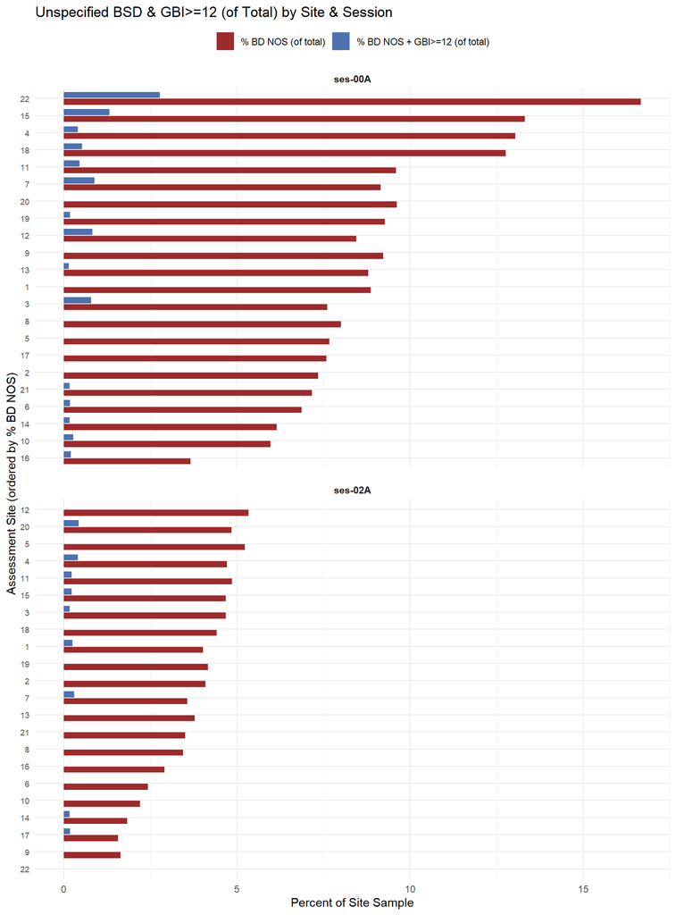

From these results, it is evident that some sites (e.g., 22 AKA Mount Sinai and 15 AKA Pitt) have a much higher incidence rate of BD NOS cases diagnosed per-capita (e.g., 16% and 13% at baseline, respectively).

However, even the lowest incidence rates for BD NOS cases at any site (i.e., 3.6% at site 16 AKA University of Utah, followed by 5.9% at site 10 AKA UCSD) exceeds the rate we would expect to observe in the population. So, while some scrutiny could be placed on diagnoses coming from specific sites (i.e., us stratifying our study participants in that way), it is likely that a more broad stratification criteria based on symptoms applied to the whole data set would be more appropriate for “trusting” the diagnoses here.

In this same vein, we will now examine the incidence and stability of BD NOS cases across the baseline and 2-year follow-up set when stratified by GBI mania scores >= 12.

Additionally, on this same topic, correspondence with Dr. Kenneth Kobak on 06/25/2025 related to the algorithms used to indicate BD NOS diagnoses in KSADS 1.0 vs 2.0 revealed that the only difference between the BD NOS diagnoses derived from KSADS 1.0 and 2.0 is the necessary presence of 1) a past or current MDD diagnosis and 2) 3 hypomania symptoms (as opposed to 2 symptoms) using KSADS 2.0.

As such, below is also another sort of spot check comparing the rates of BD NOS diagnosis across time when we stratify the cases at baseline and 2-year follow-up (i.e., derived from KSADS 1.0) by those with a part or current MDD diagnosis:

Overall Prevalence of BD NOS and Its Co-occurrence with GBI>=12 and Lifetime MDD

| Session | Total N | N NOS | % NOS | N NOS+GBI>=12 | % NOS+GBI>=12 | N NOS+MDD | % NOS+MDD | N NOS+GBI+MDD | % NOS+GBI+MDD |
| --- | --- | --- | --- | --- | --- | --- | --- | --- | --- |
| ses-00A | 11868 | 988 | 8.3 | 36 | 0.3 | 94 | 0.8 | 3 | 0 |
| ses-02A | 11868 | 431 | 3.6 | 13 | 0.1 | 48 | 0.4 | 3 | 0 |

BD NOS Transitions 00A→02A by Baseline GBI Mania Stratum

| GBI Stratum | N @00A | N no @00A | Dropped | Still Has | New | %Dropped | %NewOnset |
| --- | --- | --- | --- | --- | --- | --- | --- |
| GBI <12 | 951 | 10708 | 865 | 77 | 335 | 91.0 | 3.1 |
| GBI >=12 | 36 | 165 | 33 | 3 | 16 | 91.7 | 9.7 |
| NA | 1 | 7 | 1 | 0 | 0 | 100.0 | 0.0 |

BD NOS Transitions 00A→02A by Baseline Lifetime MDD Stratum

| MDD Stratum | N @00A | N no @00A | Dropped | Still Has | New | %Dropped | %NewOnset |
| --- | --- | --- | --- | --- | --- | --- | --- |
| MDD+ | 94 | 523 | 87 | 6 | 27 | 92.6 | 5.2 |
| MDD- | 894 | 10357 | 812 | 74 | 324 | 90.8 | 3.1 |

[output not shown]

[output not shown]

In summary of the analysis of baseline & 2-year follow-up assessment timepoint BD NOS cases stratified by the presence of a GBI clinical cut-off score and/or MDD diagnosis:

**Overall (unstratified) BD NOS Prevalence is inflated & rapidly changes across timepoints**

- KSADS v1.0 flags BD NOS in 8.3% of youth at baseline but only 3.6% two-years later. >90 % of baseline cases “drop out,” indicating low diagnostic stability rather than enduring morbidity (potentially - this could also jointly be a product of the fluctuation of BD symptoms over time)

**Symptom-based validators helps us detect a much more expected number of cases**

**Validators do not show a markedly different picture of diagnostic stability (for better or worse)**

- Within our “validated” strata, ~91 % of NOS cases remit by 2-year, and new-onset rates remain modest

**Implications for analysis**

- Restricting BD NOS at baseline/2-year to youth who also carry a lifetime MDD diagnosis sharply reduces over-diagnosis but still yields an unstable, small group
- Down-stream models should therefore a) focus on the validated BD-I/II definitions, and b) treat NOS cases conservatively, e.g., include only MDD-validated NOS

## 10. Operationalization of Outcome Variables

Below is the coding scheme we will carry forward into all survival, longitudinal, and sensitivity models. Every choice is anchored to the empirical patterns uncovered in Sections 5-9 of the EDA (instability, site effects, validator yields)

### 10.1 Primary Bipolar‐Spectrum Outcomes (binary, per wave)

[output not shown]

*Informant logic*: parent *or* youth endorsement = 1 (maximizes sensitivity; parent-only and “double-endorsement” rules will be sensitivity analyses)

### 10.2 Suicidality Outcomes (binary, per wave; scored **only among Any BSD**)

- **Passive SI**: any passive ideation flag (past or current)
- **Active SI**: any active ideation flag (method / intent / plan; past or current)
- **Suicide Attempt**: interrupted, aborted, or actual attempt (past or current)
- **NSSI**: non-suicidal self-injury (past or current)

*Why restricted to BSD*: keeps interpretation within a bipolar context; Section 6 showed extremely low BSD persistence, so suicidality is analysed at the same time rather than as lifetime carry-forward

### 10.3 Secondary Symptom Outcomes (continuous)

- CBCL DSM-5 Depression T, Anxiety T, Attention T, Aggression T
- Raw T-scores used; LMM residuals will be inspected and √/log transforms or gamma GLMMs deployed if required (EDA sec 3)

### 10.4 Sensitivity Analyses Already Planned

[output not shown]

### 10.5 Modelling Framework (brief)

- **Discrete-time survival** for first incident BD-I, BD-II, Any BSD, SI, SA, NSSI starting Year-2; prevalent baseline cases removed from risk set but covaried
- **Wave‐specific mixed-effects prevalence** (BD & suicidality), random intercepts for participant & family
- **CBCL mixed models** for symptom severity trajectories

Covariates will include: sex, age (time-varying), clustering solution, baseline diagnosis where relevant, family ID random effect, assessment site (possible random effect if model convergence allows)